# Week 11: Flexible Regression - Part 2

PS 818 - Statistical Models

Anton Strezhnev

strezhnev@wisc.edu

University of Wisconsin-Madison

November 10, 2025

$$\require{cancel}
\DeclareMathOperator*{\argmin}{arg\,min}$$

$$\DeclareMathOperator*{\argmax}{arg\,max}$$

# Previously

$$\DeclareMathOperator*{\argmax}{arg\,max}$$

- **Flexible functional forms**
  - Model $E[Y|X] = f(x)$ as a linear combination of **basis functions**
  - Polynomial bases
  - Step-function bases
  - Splines as a compromise between the two!
- **Regularization**
  - Many regressors $\leadsto$ overfitting
  - Penalize fits with many *extreme* covariates pull estimates towards zero.
  - L2 penalty (“ridge regression”) - equivalent to Bayesian normal regression
  - L1 penalty (“lasso”) - sparse solutions w/ many coefficients set to zero.

# This week

- **Kernels**
  - “Kernel smoothing” - Kernels as a “localization” tool
  - “Kernel methods” - Kernels as regression inputs
  - Two *different* uses of the term/concept - but some interesting relations
- **Forests**
  - Tree-based models for classification and regression
  - Ensembles/averages of trees via **random forests**
  - Diagnostics via “variable smoothing”
  - Extensions to detecting causal heterogeneity

# Kernel smoothing

# Example: Modeling Bike Rentals

- Recall again our **bikeshare usage** dataset
  - Fanaee-T, Hadi, and Gama, Joao, “Event labeling combining ensemble detectors and background knowledge”, *Progress in Artificial Intelligence* (2013): pp. 1-15

```r
bike <- read_csv("data/bikes_hour.csv")
bike_by_hour <- bike %>% group_by(hr) %>% summarize(cnt = mean(cnt))
```

# Example: Modeling Bike Rentals

- Our most intuitive approach to estimating the CEF was to just take the **average** for a given hour of the day

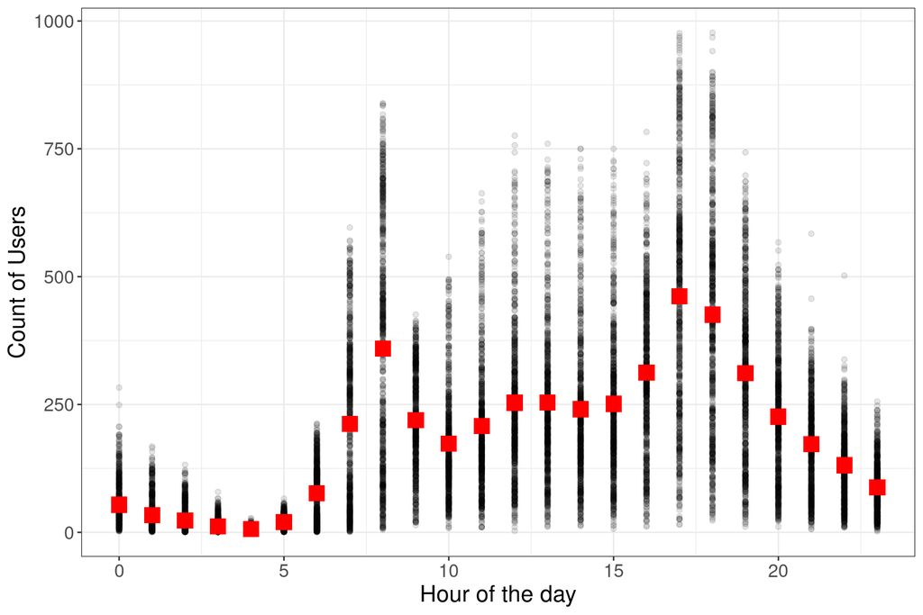

# Kernel smoothing

- One downside - I can only evaluate the function at each discrete hour.
  - What would I predict is the usage at 7:45pm?
  - Intuitively, I would want to take the average of the “nearest data points”
- **Kernel smoothing** methods give us a straightforward, non-parametric approach to estimating $f(x) = E[Y|X=x]$ without making strong assumptions about the functional form of the CEF.
  - “weighted average” of “similar” observations
- We define the similarity between two points $x_0$ and $x$ by way of a **kernel function** $K_h()$

  $$K_h(x_0, x) = D\bigg(\frac{|x - x_0|}{h(x_0)}\bigg)$$
- $D$ is our particular choice of kernel function and $h(x_0)$ is the “bandwidth” or “window size”
  - Often use a constant bandwidth that does not depend on the inputs $h(x_0) = h$
- The kernel function is **symmetric** and **non-negative**

# Kernel smoothing

- Uniform kernel

$$D(u) = \begin{cases} \frac{1}{2} &\text{ if } |u| \le 1\\
0 & \text{ otherwise}\end{cases}$$

- Triangular kernel

$$D(u) = \begin{cases} 1 - |u| &\text{ if } |u| \le 1\\
0 & \text{ otherwise}\end{cases}$$

- Gaussian (or “radial basis”) kernel

# Kernel smoothing

```r
uniform_kernel <- function(x) {
  ifelse(abs(x) <= 1, 1/2, 0)
}

triangular_kernel <- function(x) {
  ifelse(abs(x) <= 1, 1 - abs(x), 0)
}

gaussian_kernel <- function(x) {
  (1 / sqrt(2 * pi)) * exp(-0.5 * x^2)
}
```

# Kernel smoothing

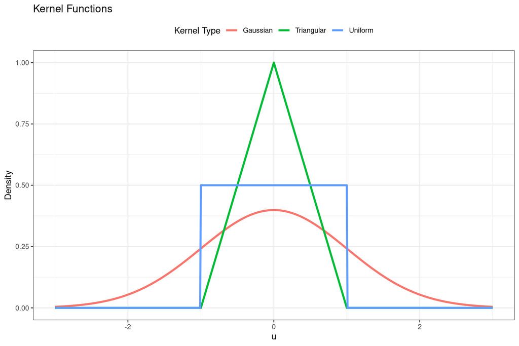

# Nadaraya-Watson estimator

- For a set of $N$ observations indexed by $i$ $\{y_i, x_i\}$ and given a kernel function $K_h()$ and a chosen bandwidth $h$, the **Nadarya-Watson** estimator of $f(x) = E[Y|X = x]$ is:

$$\hat{f}(x) = \frac{\sum_{i=1}^n K_h(x - x_i)y_i}{\sum_{i=1}^n K_h(x - x_i)}$$

- Our best prediction for $Y$ at $x$ is the average of the observed $y_i$, weighted by the “closeness” of their corresponding $x_i$ to the input $x$.
- Some intuitions:
  - **Larger bandwidths** = more influence from “further” points (lower variance, higher bias)
  - **Smaller bandwidths** = only “close” points have meaningful weight (higher variance, lower bias)

# Example: Modeling Bike Rentals

- In R, local kernel smoothing methods are implemented in the package `np`

```r
library(np)
```

- We’ll start with a uniform kernel and a bandwidth of 3

```r
kernel_reg <- npreg(cnt ~ hr, data=bike, ckertype="uniform", bws = 3, regtype='lc')
summary(kernel_reg)
```

```
Regression Data: 17379 training points, in 1 variable(s)
              hr
Bandwidth(s):  3

Kernel Regression Estimator: Local-Constant
Bandwidth Type: Fixed
Residual standard error: 138
R-squared: 0.427

Continuous Kernel Type: Uniform
No. Continuous Explanatory Vars.: 1
```

# Example: Modeling Bike Rentals

- Generate predictions on a sequence of points and plot the line

```r
kernel_predict <- data.frame(hr = seq(0, 23, by=.01),
                             cnt = predict(kernel_reg, newdata=data.frame(hr = seq(0, 23, by=.01))))
```

# Example: Modeling Bike Rentals

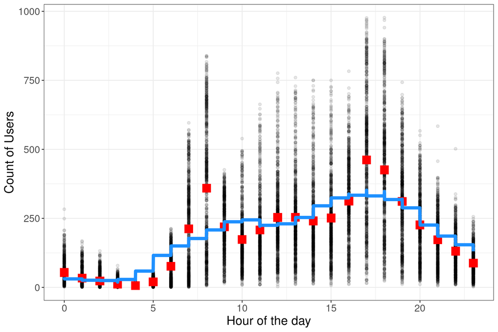

# Example: Modeling Bike Rentals

- What about if we use a gaussian kernel

```r
gaussian_kernel <- npreg(cnt ~ hr, data=bike, ckertype="gaussian", bws = 3, regtype='lc')
summary(gaussian_kernel)
```

```
Regression Data: 17379 training points, in 1 variable(s)
              hr
Bandwidth(s):  3

Kernel Regression Estimator: Local-Constant
Bandwidth Type: Fixed
Residual standard error: 147
R-squared: 0.355

Continuous Kernel Type: Second-Order Gaussian
No. Continuous Explanatory Vars.: 1
```

```r
gaussian_predict <- data.frame(hr = seq(0, 23, by=.01),
                             cnt = predict(gaussian_kernel, newdata=data.frame(hr = seq(0, 23, by=.01))))
```

# Example: Modeling Bike Rentals

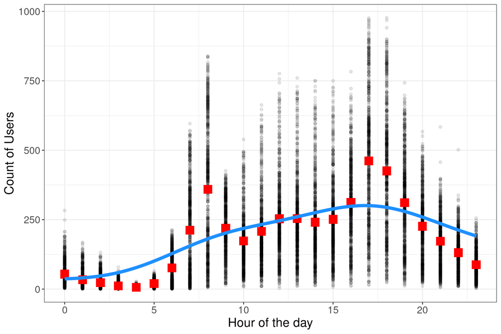

# Example: Modeling Bike Rentals

- What happens with a narrower bandwidth?

```r
gaussian_kernel_2 <- npreg(cnt ~ hr, data=bike, ckertype="gaussian", bws = 1, regtype='lc')
summary(gaussian_kernel_2)
```

```
Regression Data: 17379 training points, in 1 variable(s)
              hr
Bandwidth(s):  1

Kernel Regression Estimator: Local-Constant
Bandwidth Type: Fixed
Residual standard error: 131
R-squared: 0.478

Continuous Kernel Type: Second-Order Gaussian
No. Continuous Explanatory Vars.: 1
```

```r
gaussian_predict_2 <- data.frame(hr = seq(0, 23, by=.01),
                             cnt = predict(gaussian_kernel_2, newdata=data.frame(hr = seq(0, 23, by=.01))))
```

# Example: Modeling Bike Rentals

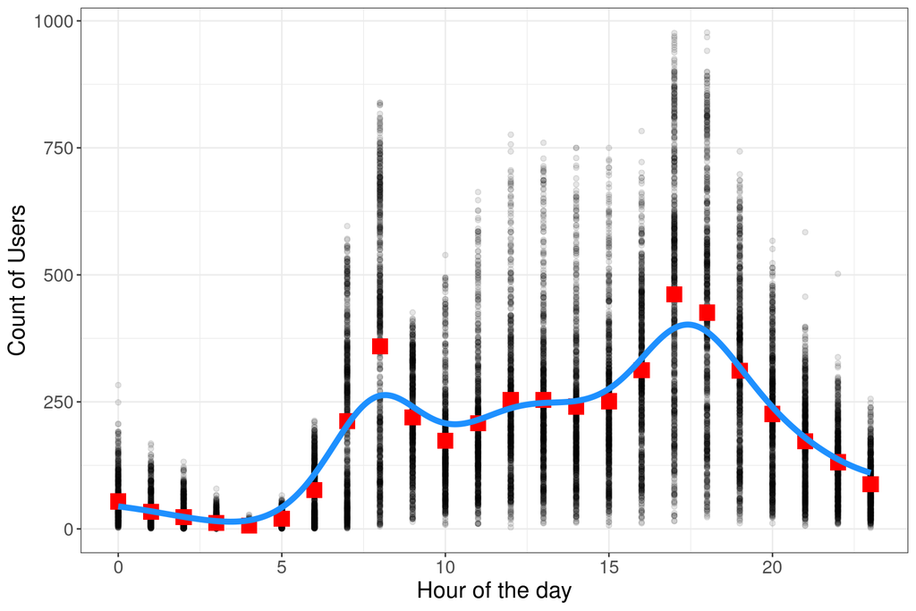

# Local linear regression

- Instead of just making our prediction a weighted average, we can incorporate a least-squares adjustment
  - Fit a **line** rather than a **constant**
- Our prediction for $f(x)$ is defined as the solution to the **least-squares** problem in terms of intercept $\alpha(x)$ and slope $\beta(x)$

$$\sum_{i=1}^n K_h(x, x_i)[y_i - \alpha(x) - \beta(x) x_i]$$

- Let’s fit this with `np` using a uniform kernel and a narrow bandwidth.

```r
uniform_local_linear <- npreg(cnt ~ hr, data=bike, ckertype="uniform", bws = 2, regtype='ll')
uniform_predict_ll <- data.frame(hr = seq(0, 23, by=.01),
                             cnt = predict(uniform_local_linear, newdata=data.frame(hr = seq(0, 23, by=.01))))
```

# Example: Modeling Bike Rentals

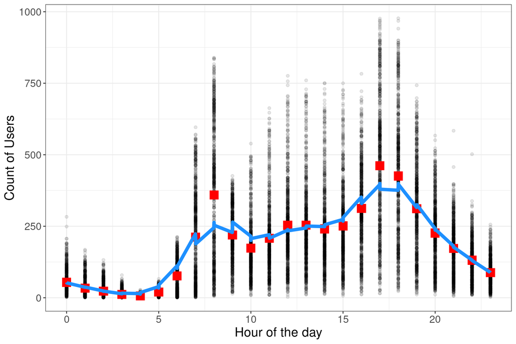

# Kernel Methods

# Regression as optimization

- Throughout this course and previous courses, our goal has been to find some function $f(x)$ of inputs $x$ that acts as a “best predictor” of $Y$
  - We define some objective function $\mathcal{L}$ and attempt to minimize/maximize it
  - Least squares; maximum likelihood
- Given a set of $n$ inputs, $\{x_i, y_i\}$, we want to find a function that solves

$$\hat{f} = \argmin_{f} \ \mathcal{L}\bigg(\{x_i, y_i\}_{i=1}^n\bigg)$$

# Space of functions

- So far, we’ve placed severe constraints on the space of functions over which we search.
- **Linear functions**

$$f(x) = \beta_0 + \beta_1x_1 + \beta_2x_2 + \beta_3x_3 + \dotsc$$

- **Basis expansion**

$$f(X) = \sum_{m=1}^M \beta_m h_m(X)$$

- Can we be more flexible than this while still retaining computational feasibility?

# Space of functions defined by kernels

- “Kernel methods” consider searching over a space of functions defined implicitly by a positive-definite kernel function.
  - Example, the **Gaussian** kernel

$$K(x, x^\prime) = \exp\bigg(-\frac{||x - x^\prime||^2}{2\sigma^2}\bigg)$$

- We’ll consider a search over a set of functions defined by a linear combination of kernels evaluated at the input points in our data

$$f(x) = \sum_{i=1}^N c_i K(x, x_i)$$

- What is this space of functions? How “flexible” is it?

# Reproducing Kernel Hilbert Spaces

- A positive semi-definite kernel function $K(x, x^\prime)$ corresponds to a space of functions known as a “reproducing kernel Hilbert space” (RKHS).
  - A choice of kernel implies a mapping $\phi(x)$ that transforms the input vector $x$ into a higher dimensional (possibly infinite dimensional) space.
  - This space is equipped with an inner product $\langle \cdot, \cdot\rangle$ such that for any two functions, the inner product is given by an evaluation of the kernel at the inputs

$$K(x, x^\prime) = \langle \phi(x), \phi(x^\prime)\rangle$$

- We can write $K(x, y)$ as an eigen-function expansion:

$$K(x, x^\prime) = \sum_{i=1}^\infty \gamma_i \phi_i(x)\phi_i(x^\prime)$$

- where

$$\phi(x) = \sum_{i=1}^\infty c_i \phi_i(x)$$

# Reproducing Kernel Hilbert Spaces

- With some regularity conditions on $c_i$ and $\gamma_i$, we can “represent” an evaluation of $\phi(x)$ by way of an inner product

$$\phi(x_i) = \langle \phi, K(\cdot, x_i) \rangle$$

- As a result, we can work in the space of $\phi$ without ever having to evaluate $\phi$ directly - only its kernel.

# “The Kernel Trick”

- One important feature of optimization over functions defined over a reproducing kernel Hilbert space is that even if the functions in the space are **infinite dimensional** - solutions to optimization problems are necessarily **finite dimensional** and have the form of a linear combination of kernels.
- The **representer theorem** states that for minimization problems of the form:

$$\hat{f} = \argmin_{f} \mathcal{L}(\{x_i, y_i\}_{i=1}^n) + \lambda||f||^2$$

the solution is a finite sum of weighted kernel functions

$$\hat{f} = \sum_{i=1}^n \hat{c}_i K(x, x_i)$$

# Kernel Regularized Least Squares

- Intuitively, what the “kernel trick” allows us to do is design a good functional approximator by way of a conventional ridge regression estimator.
  - Relatively well-known in machine learning (particularly for classification) throughout the 2000s, but introduced to political science by **Hainmueller and Hazlett (2014)** and labeled **Kernel regularized least squares**
- Our regression matrix is constructed by creating a total of $N$ columns.
  - Each row of the “kernel regression” matrix is a linear combination of the kernel evaluated between $x_i$ and each observation in the data

$$f(x_i) = c_1K(x_i, x_1) + c_2K(x_i, x_2) + \dotsc c_n K(x_i, x_n)$$

- The regression matrix is $N \times N$
  - We need to regularize!

# Example: Interpolating spatial data

- A very common problem in spatial statistics is predicting an outcome at any given latitude/longitude coordinate given a finite set of observations at particular coordinates
  - e.g. What is the estimated average temperature given observations at a number of weather monitoring stations?
  - Finding the “best” interpolation between the observed points is known as “kriging” in the geostatistics literature
- We’ll use a sample of U.S. weather stations as an example:

```r
library(sf)
library(geosphere)
```

# Example: Interpolating spatial data

- Start by reading in the U.S. shapefile

```r
us_shapefile <- read_rds("data/us_shapefile.rds") %>%
  filter(!(STUSPS %in% c("AK", "HI", "AS", "GU", "MP", "PR", "VI")))
```

- Next, read in the NOAA Climate Assessment Database monthly weather station data from January, 2025.

```r
weather <- read_csv("data/monthly_summary_202501_v2.csv") %>% filter(country == "UNITED_STATES")
weather <- weather %>% filter(atmp > -99999&ntmp > -99999) # Missing obs hard coded as -99999
weather <- weather %>% mutate(deviation = atmp - ntmp)
weather <- weather %>% filter(!(state %in% c("AK", "HI", "AS", "GU", "MP", "UM", "PR", "VI")))
```

# Example: Interpolating spatial data

- Convert to a plotable object and overlay on the map

```r
# Convert the stations to a plottable object
weather_sf <- st_as_sf(weather, coords = c("lon", "lat"), crs = st_crs(us_shapefile), remove=F)
```

# Example: Interpolating spatial data

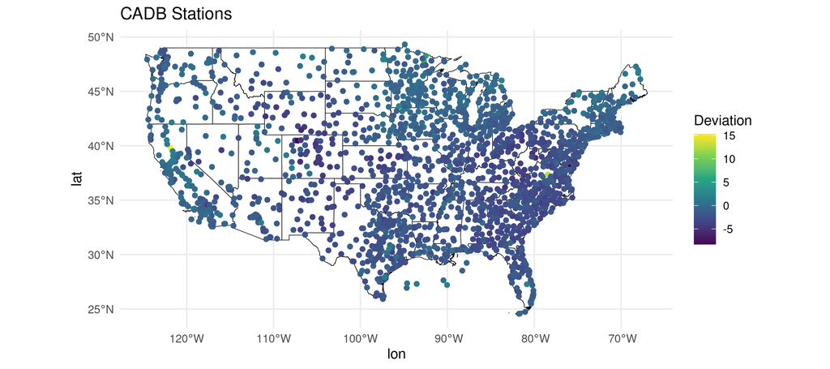

# Example: Interpolating spatial data

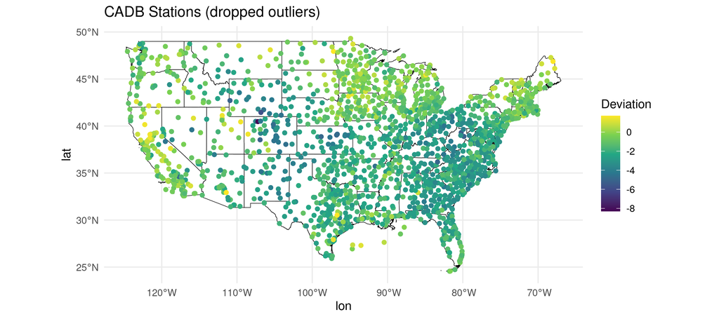

# Example: Interpolating spatial data

- We’ll make a grid of 50km squares on which to to evaluate our predictions

```r
# Set boundaries for U.S. (approximate)
lat_min <- 24.396308  # Southernmost point (Florida)
lat_max <- 49.384358  # Northernmost point (Canada border)
lon_min <- -125.0     # Westernmost point (California)
lon_max <- -66.93457  # Easternmost point (Maine)

# Approximate 50 km in degrees (this will vary by latitude, but we'll use an average factor)
lat_interval <- 50 / 110.574  # 1 degree latitude ≈ 110.574 km
lon_interval <- 50 / (111.320 * cos(mean(c(lat_min, lat_max)) * pi / 180))  # Longitude interval varies with latitude

# Create a sequence of points for latitude and longitude
latitudes <- seq(lat_min, lat_max, by = lat_interval)
longitudes <- seq(lon_min, lon_max, by = lon_interval)

# Create a grid of all combinations of latitudes and longitudes
grid_points <- expand.grid(lat = latitudes, lon = longitudes)

# Convert the grid points to an 'sf' object
grid_points_sf <- st_as_sf(grid_points, coords = c("lon", "lat"), crs = st_crs(us_shapefile), remove=F)

# Filter grid points to keep only those within the U.S. boundary
grid_points_within_us <- st_intersection(grid_points_sf, us_shapefile)
```

# Example: Interpolating spatial data

- Simple linear regression seems to miss a lot of the geographic nuances.

```r
weather_linear <- lm(deviation ~ lat + lon + lat*lon, data=weather)
grid_points_within_us$linpredict <- predict(weather_linear, newdata=grid_points_within_us)
```

# Example: Interpolating spatial data

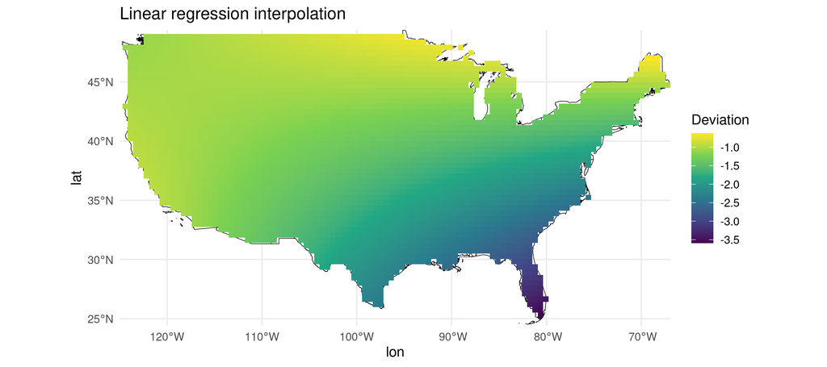

# Kernel Regularized Least Squares

- What happens when we fit KRLS with latitude and longitude as the covariate inputs.

```r
library(KRLS)
```

- Estimate the model
  - We use the default Hainmueller and Hazlett (2014) approach to setting the bandwidth equal to the number of dimensions in the data.
  - Standard leave-one-out cross-validation of the penalty parameter

```r
krls_reg <- krls(X = model.matrix(~lat + lon, data=weather)[,-1],
                 y = weather$deviation,
                 whichkernel = "gaussian",
                 vcov=F,
                 derivative=F)
```

# Kernel Regularized Least Squares

- What do the inputs look like?

```r
dim(krls_reg$K)
```

```
[1] 1825 1825
```

```r
head(krls_reg$K[,1])
```

```
       1        2        3        4        5        6
1.00e+00 6.90e-07 1.38e-06 2.62e-06 8.33e-06 1.22e-05
```

```r
head(krls_reg$K[,2])
```

```
       1        2        3        4        5        6
6.90e-07 1.00e+00 9.69e-01 9.17e-01 8.01e-01 7.69e-01
```

```r
head(krls_reg$K[,3])
```

```
       1        2        3        4        5        6
1.38e-06 9.69e-01 1.00e+00 9.86e-01 9.11e-01 8.83e-01
```

# Kernel Regularized Least Squares

- What do the inputs look like?

```r
hist(krls_reg$K)
```

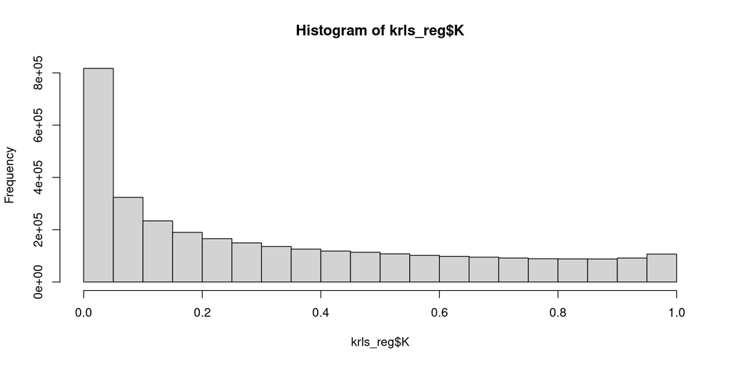

# Kernel Regularized Least Squares

- Predict using the KRLS regression for each of our grid squares.

```r
grid_points_within_us$krlspredict <- predict(krls_reg, newdata= model.matrix(~lat + lon, data=grid_points_within_us)[,-1])$fit
```

# Kernel Regularized Least Squares

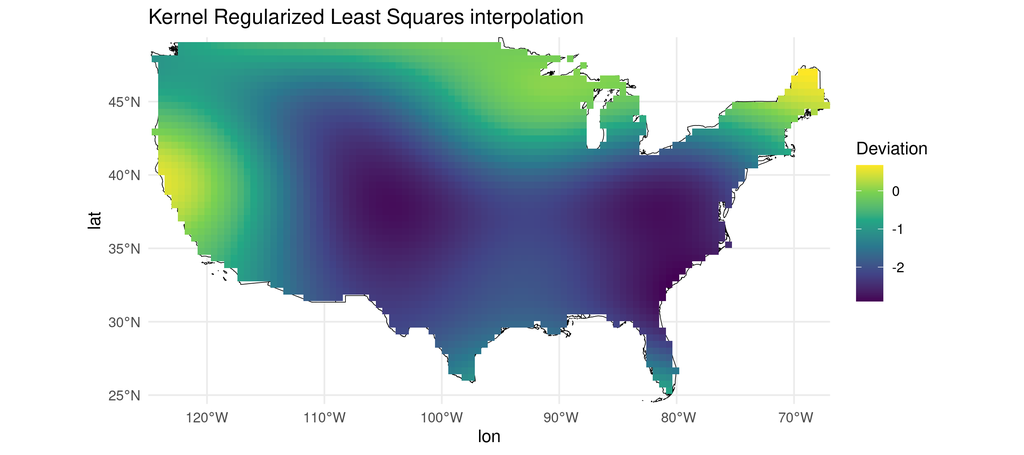

# Kernel Regularized Least Squares

- What if we chose a smaller bandwidth for the Gaussian kernel?

```r
krls_reg_2 <- krls(X = model.matrix(~lat + lon, data=weather)[,-1],
                 y = weather$deviation,
                 sigma = 1/5,
                 whichkernel = "gaussian",
                 vcov=F,
                 derivative=F)
```

# Kernel Regularized Least Squares

- Predict using the KRLS regression for each of our grid squares.

```r
grid_points_within_us$krlspredict2 <- predict(krls_reg_2, newdata= model.matrix(~lat + lon, data=grid_points_within_us)[,-1])$fit
```

# Kernel Regularized Least Squares

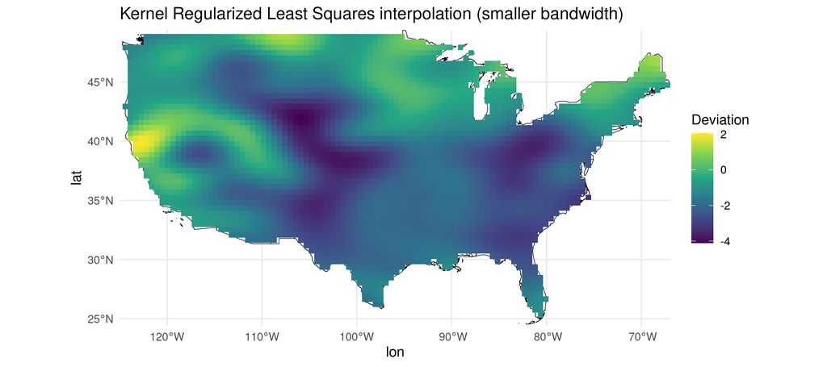

# Trees and (Random) Forests

# Classification and Regression Trees

- An alternative way of thinking about the task of predicting $Y$ from $X$ is in terms of **decision trees**
  - Given some input $X$ can we come up with a “flow chart” that will generate a good predicction for $Y$ based on a series of yes/no splits?
- Each **tree** is a sequence of **nodes**
  - At each **node**, we split the tree based on the observed value of a particular covariate
  - Continue to follow the path of the tree (splitting on other covariates) until we reach the bottom of the tree
  - Output is either a **classification** (binary/discrete outcomes) or an **expectation** of $Y$ (regression)
- The tree **partitions** the space into $M$ regions $R_1, R_2, R_3, \dotsc, R_M$.
  - Our predicted value of $Y$ given input $X$ is

$$f(X) = \sum_{m=1}^M c_m \mathbf{I}(X \in R_m)$$

where $c_m$ is our “best prediction” for Y in a given bin (typically the mean for squared loss)

# Recursive partitioning

- How do we figure out the partitions for a given tree?
  - (1): For each variable, find a splitting point that minimizes the **within-partition** variance
  - (2): Split on the single variable that provides the **best split** among these variables
  - (3): Repeat 1/2 on each **sub-sample** created by the previous split.
  - (4): Continue until stopping conditions reached
- How large should we grow the tree?
  - If we split on every covariate, we’re likely to **overfit**!
  - Could tune **tree depth** but inefficient splits could lead to more efficient ones
- **Cost-Complexity** pruning
  - (1): Grow a **large** tree until we hit some minimum node size (e.g. all nodes have fewer than 5 observations)
  - (2): Recombine splits that don’t improve fit above some minimum threshold

# Decision trees

- A popular package for implementing tree-based methods is `caret` (Classification and Regression Training)
  - Contains wrapper functions for various methods and makes optimizing over the tuning parameters a lot easier!

```r
library(caret)
library(rpart)
```

- We’ll start by just showing **one** regression tree applied to our temperature data applying the recursive partitioning algorithm
  - Use the default training parameters

```r
temp_tree <- rpart(deviation ~ lat + lon,
                  data = weather)
```

# Decision trees

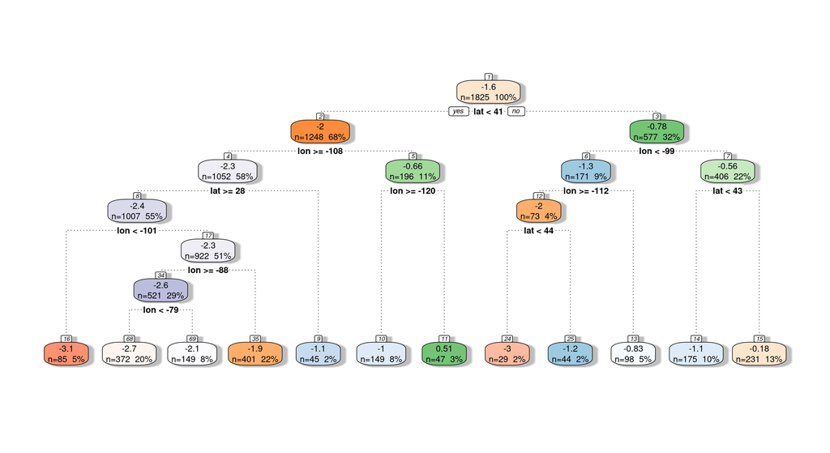

# Decision trees

- Predict for each of our grid squares.

```r
grid_points_within_us$dtpredict <- predict(temp_tree, newdata= grid_points_within_us)
```

# Decision trees

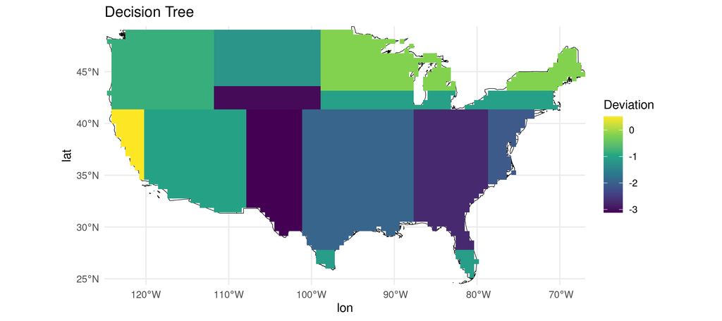

# Random forests

- A single tree outputs a sharp classification boundary
  - Potentially noisy predictions!
  - And the relationship between $Y$ and $X$ may be smooth!
  - And we might be concerned that a single tree **overfits** to the data.
- Solution: **Grow a forest of trees** and **average** over the predictions!
- **Random forests** (Breiman, 2001) improve on individual trees using two techniques:
  - **Bagging** (bootstrap aggregating) - Grow separate trees on bootstrap samples of the data
  - **De-correlating** - Use random subsets of *features* in each tree.
- Our predictions are an **average** of predictions across trees
  - Can get arbitrarily smooth prediction surfaces given a larger and larger forest
  - Model evaluation via **out-of-bag** predictions (evaluate on observations that *don’t* get sampled in each bootstrap)

# Random forests

- Let’s instead grow **many trees** - each tree is grown on a bootstrapped version of the data and generates a different set of splits!

```r
set.seed(60639)
temp_rf <- train(deviation ~ lat + lon,
                  data = weather, method = "ranger")
```

# Random forests

- Predict using the random forests for each of our grid squares.

```r
grid_points_within_us$rfpredict <- predict(temp_rf, newdata= model.matrix(~lat + lon, data=grid_points_within_us)[,-1])
```

# Random forests

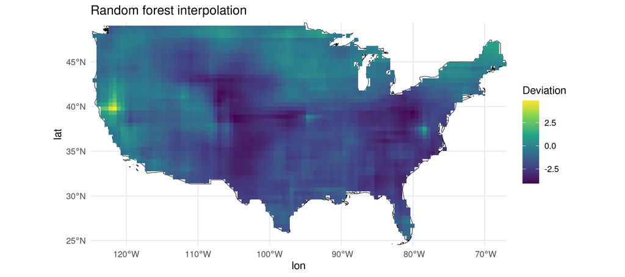

# Example: Predicting Peace Agreements

- Random forests are particularly valuable in settings with a **large number** of covariates where we’re concerned about over-fitting.
  - Let’s go back to our **UCDP Peace agreements** example

```r
pa <- read_csv("data/ucdp-peace-agreements-221.csv")
```

- Some brief pre-processing of the outcome

```r
# If agreement remains, then duration = "now"
pa$duration_complete <- pa$duration
pa$duration[is.na(pa$duration)] <- ymd("2021-12-31")
pa$durationDays <- as.numeric(pa$duration - pa$pa_date)
# Fill in missing "ended' data
pa$ended_full <- as.numeric(pa$ended)
pa$ended_full[is.na(pa$ended_full)] <- 0
```

# Example: Predicting Peace Agreements

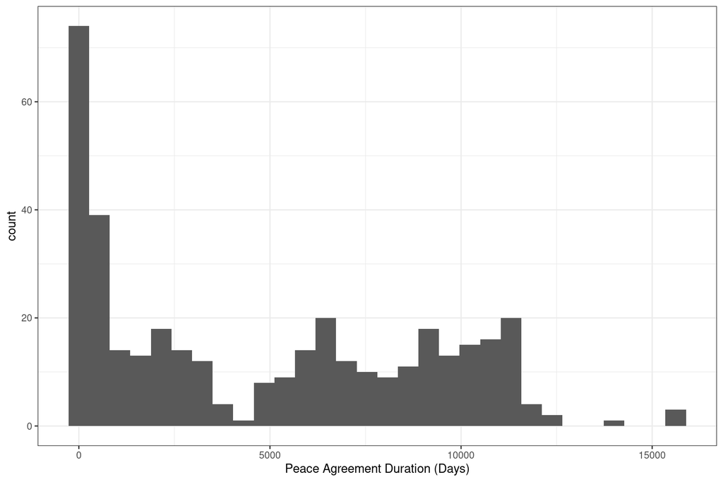

# Example: Predicting Peace Agreements

```r
set.seed(60639)
pa_rf <- train(durationDays ~ as.factor(region) + year + as.factor(incompatibility) +
                       cease + intarmy + ddr + withd + mil_prov + pp + intgov + intciv +
                       elections + interim + natalks + shagov + pol_prov + aut + fed + ind +
                       ref + shaloc + regdev + cul + demarcation + locgov + terr_prov + amn +
                       pris + recon + return + justice_prov + reaffirm + outlin + pko + gender +
                       co_impl + termdur + txt + as.factor(inclusive) + as.factor(pa_type) +
                       as.factor(out_iss) + as.factor(frame),
              importance = 'impurity',
              data=pa,
              method = "ranger")
```

# Example: Predicting Peace Agreements

```r
print(pa_rf)
```

```
Random Forest

374 samples
 42 predictor

No pre-processing
Resampling: Bootstrapped (25 reps)
Summary of sample sizes: 374, 374, 374, 374, 374, 374, ...
Resampling results across tuning parameters:

  mtry  splitrule   RMSE  Rsquared  MAE
   2    variance    3805  0.306     3323
   2    extratrees  3864  0.271     3402
  28    variance    3339  0.396     2407
  28    extratrees  3494  0.339     2644
  54    variance    3336  0.397     2335
  54    extratrees  3480  0.343     2533

Tuning parameter 'min.node.size' was held constant at a value of 5
RMSE was used to select the optimal model using the smallest value.
The final values used for the model were mtry = 54, splitrule = variance
 and min.node.size = 5.
```

# Variable importance

- With many covariates, we may want to know which variables are most **relevant** for making predictions.
- Two approaches
  - **Impurity** - How much do all the splits on a given variable improve prediction quality (e.g. outcome variance)
  - **Permutation** - If we reshuffled the values of a particular variable, how much would it reduce predictive accuracy?
- We can access this with the `varImp` function in `caret` if we fit a model that returns an importance criterion

```r
pa_varimportance <- varImp(pa_rf)
```

# Variable importance

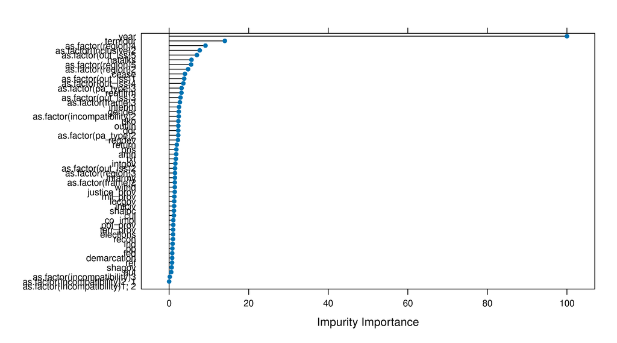

# Variable importance

- One downside with “impurity” is that it will tend to favor covariates with a lot of levels (see the high weight on “year” above)
  - Let’s compare to “permutation”

```r
set.seed(60639)
pa_rf_perm <- train(durationDays ~ as.factor(region) + year + as.factor(incompatibility) +
                       cease + intarmy + ddr + withd + mil_prov + pp + intgov + intciv +
                       elections + interim + natalks + shagov + pol_prov + aut + fed + ind +
                       ref + shaloc + regdev + cul + demarcation + locgov + terr_prov + amn +
                       pris + recon + return + justice_prov + reaffirm + outlin + pko + gender +
                       co_impl + termdur + txt + as.factor(inclusive) + as.factor(pa_type) +
                       as.factor(out_iss) + as.factor(frame),
              importance = 'permutation',
              data=pa,
              method = "ranger")
```

# Variable importance

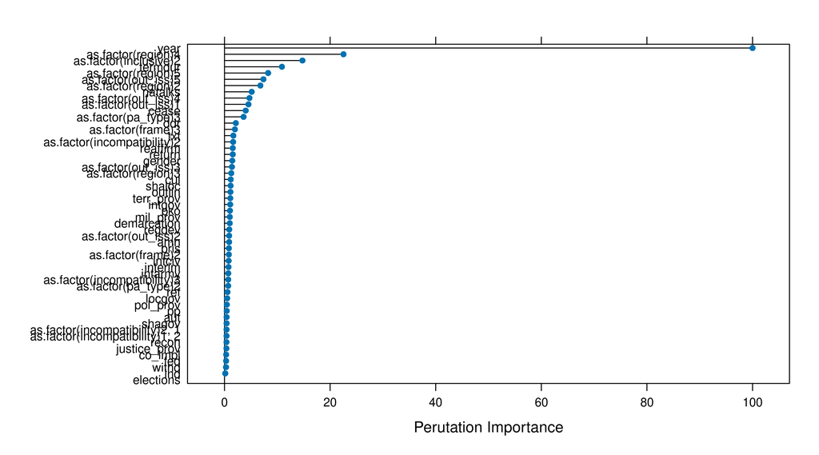

# Partial dependence plots

- We may want to get a sense of how the predictions change with respect to a given predictor
  - What is the **marginal density** of $Y$ with respect to some predictor $X_i$, averaged over all other predictors $X_{-i}$?
- The `pdp` package allows us to do this for `ranger` objects

```r
library(pdp)
```

# Partial dependence plots

- `partial` will generate a data frame of predictions for each value of our chosen predictor variable

```r
partial_year <- partial(pa_rf,
pred.var = c("year"),
paropts = list(.packages = "ranger"))
```

# Partial dependence plots

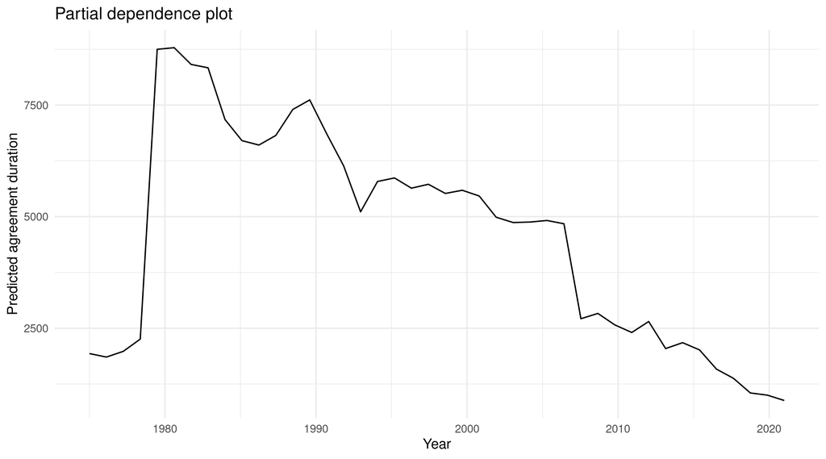